# EPA Code Vignette

Author

George Hagstrom

## Introduction

I decided to use `httr2` to explore the EPA air quality services API. This API contains a number of difference services which let you download different types of measurements from air quality sensors located around the country. The documentation for this API is located here: https://aqs.epa.gov/aqsweb/documents/data_api.html.

## Accessing the API to Download PM2.5 Data from a Sensor in Manhattan

The goal of this code will be to locate a sensor in Manhattan which takes PM2.5 data, download the data, and make a plot of the data.

I begin by defining some code which I will use to build up requests

```r
library(httr2)
library(tidyverse)
library(jsonlite)
library(tibblify)
library(lubridate)

epa_email = "georgehagstrom@gmail.com"

epa_url = "https://aqs.epa.gov/data/api/"
epa_key = read_csv("/home/georgehagstrom/work/Teaching/DATA607/website/meetups/Meetup10/epa_key.csv") |>
  pull(key)
# This creates a blank request targetted at the epa_url

epa_req = epa_url |> request() |>
  req_url_query(
    email = epa_email
  )



# We are going to need to download some lists to figure out how to find things we are interested in

epa_classes_url = "list/classes"

epa_counties_url = "list/countiesByState"

epa_states_url = "list/states"

epa_pars_url = "list/parametersByClass"

# Which is New York State?

epa_req_states = epa_req |>
  req_url_path_append(epa_states_url) |>
  req_url_query(
    key = epa_key
  )

states_list = epa_req_states |> req_perform() |>
  resp_body_json()



states_list$Data |> tibblify() |> filter(code == "New York")
```

```
# A tibble: 0 × 2
# ℹ 2 variables: code <chr>, value_represented <chr>
```

Next we look at the counties, with the goal of finding New York county:

```r
epa_req_counties = epa_req |>
  req_url_path_append(epa_counties_url) |>
  req_url_query(
    key = epa_key,
    state = "36"
  )

counties_list = epa_req_counties |>
  req_perform() |>
  resp_body_json()


counties_list$Data |> tibblify() |> filter(code == "New York")
```

```
# A tibble: 0 × 2
# ℹ 2 variables: code <chr>, value_represented <chr>
```

The next step is to identify the parameter code for some PM2.5 measurement. To do this, we first need to explore the list of parameter classes, so we will query the `list/classes` endpoint:

```r
epa_classes_list = epa_req |>
  req_url_path_append(epa_classes_url) |>
  req_url_query(
    key = epa_key
  ) |>
  req_perform() |>
  resp_body_json()

epa_classes_list$Data |> tibblify() |> print(n=27)
```

```
# A tibble: 27 × 2
   code                    value_represented
   <chr>                   <chr>
 1 AIRNOW MAPS             The parameters represented on AirNow maps (88101, 88…
 2 ALL                     Select all Parameters Available
 3 AQI POLLUTANTS          Pollutants that have an AQI Defined
 4 CORE_HAPS               Urban Air Toxic Pollutants
 5 CRITERIA                Criteria Pollutants
 6 CSN DART                List of CSN speciation parameters to populate the ST…
 7 FORECAST                Parameters routinely extracted by AirNow (STI)
 8 HAPS                    Hazardous Air Pollutants
 9 IMPROVE CARBON          IMPROVE Carbon Parameters
10 IMPROVE_SPECIATION      PM2.5 Speciated Parameters Measured at IMPROVE sites
11 MET                     Meteorological Parameters
12 NATTS CORE HAPS         The core list of toxics of interest to the NATTS pro…
13 NATTS REQUIRED          Required compounds to be collected in the National A…
14 PAMS                    Photochemical Assessment Monitoring System
15 PAMS_VOC                Volatile Organic Compound subset of the PAMS Paramet…
16 PM COARSE               PM between 2.5 and 10 micrometers
17 PM10 SPECIATION         PM10 Speciated Parameters
18 PM2.5 CONT NONREF       PM2.5 Continuous, Nonreference Methods
19 PM2.5 MASS/QA           PM2.5 Mass and QA Parameters
20 SCHOOL AIR TOXICS       School Air Toxics Program Parameters
21 SPECIATION              PM2.5 Speciated Parameters
22 SPECIATION CARBON       PM2.5 Speciation Carbon Parameters
23 SPECIATION CATION/ANION PM2.5 Speciation Cation/Anion Parameters
24 SPECIATION METALS       PM2.5 Speciation Metal Parameters
25 UATMP CARBONYL          Urban Air Toxics Monitoring Program Carbonyls
26 UATMP VOC               Urban Air Toxics Monitoring Program VOCs
27 VOC                     Volatile organic compounds
```

We were able to identify `"PM2.5 CONT NONREF"`. We will use this to query the `list/parametersByClass` endpoint:

```r
pm2.5code = "PM2.5 CONT NONREF"

epa_pm2.5pars_list = epa_req |>
  req_url_path_append(epa_pars_url) |>
  req_url_query(
    email = epa_email,
    key = epa_key,
    pc = pm2.5code
  ) |>
  req_perform() |>
  resp_body_json()

epa_pm2.5pars_list$Data |> tibblify()
```

```
# A tibble: 4 × 2
  code  value_represented
  <chr> <chr>
1 88500 PM2.5 Total Atmospheric
2 88501 PM2.5 Raw Data
3 88502 Acceptable PM2.5 AQI & Speciation Mass
4 88503 PM2.5 Volatile Channel
```

We were able to identify it as `88501`.

Next we will search the `monitors/byCounty` endpoint to identify monitors in New York county that measure parameter `88501`, which is our PM2.5 measurement.

```r
county_endpoint = "monitors/byCounty"


epa_req_county_monitors = epa_req |>
  req_url_path_append(county_endpoint) |>
  req_url_query(
    key = epa_key,
    county = "061",
    param = "88501",
    bdate = "20150101",
    edate = "20240930",
    state = "36"
  )

county_monitor_list = epa_req_county_monitors |> req_perform() |> resp_body_json()

county_monitor_list$Data |> tibblify()
```

```
The spec contains 5 unspecified fields:
• concurred_exclusions
• naaqs_primary_monitor
• qa_primary_monitor
• tribal_code
• tribe_name
```

```
# A tibble: 4 × 41
  state_code county_code site_number parameter_code   poc parameter_name
  <chr>      <chr>       <chr>       <chr>          <int> <chr>
1 36         061         0115        88501              3 PM2.5 Raw Data
2 36         061         0134        88501              3 PM2.5 Raw Data
3 36         061         0135        88501              3 PM2.5 Raw Data
4 36         061         0128        88501              3 PM2.5 Raw Data
# ℹ 35 more variables: open_date <chr>, close_date <chr>,
#   concurred_exclusions <list>, dominant_source <chr>,
#   measurement_scale <chr>, measurement_scale_def <chr>,
#   monitoring_objective <chr>, last_method_code <chr>,
#   last_method_description <chr>, last_method_begin_date <chr>,
#   naaqs_primary_monitor <list>, qa_primary_monitor <list>,
#   monitor_type <chr>, networks <chr>, monitoring_agency_code <chr>, …
```

We identify `0135` as one potential sensor with such data.

We are going to pull one year of data from this sensor from the `sampleData/bySite` endpoint:

```r
site = "0135"

data_by_site_url = "sampleData/bySite"

epa_req_sample = epa_req |>
  req_url_path_append(data_by_site_url) |>
  req_url_query(
    key = epa_key,
    site = site,
    param = "88501",
    state = "36",
    county = "061",
    bdate = "20080101",
    edate = "20081231"
  )


epa_sample_data = epa_req_sample |> req_perform() |>
  resp_body_json()

epa_sample_data$Data |> tibblify()
```

```
The spec contains 2 unspecified fields:
• uncertainty
• date_of_last_change
```

```
# A tibble: 8,783 × 29
   state_code county_code site_number parameter_code   poc latitude longitude
   <chr>      <chr>       <chr>       <chr>          <int>    <dbl>     <dbl>
 1 36         061         0135        88501              3     40.8     -73.9
 2 36         061         0135        88501              3     40.8     -73.9
 3 36         061         0135        88501              3     40.8     -73.9
 4 36         061         0135        88501              3     40.8     -73.9
 5 36         061         0135        88501              3     40.8     -73.9
 6 36         061         0135        88501              3     40.8     -73.9
 7 36         061         0135        88501              3     40.8     -73.9
 8 36         061         0135        88501              3     40.8     -73.9
 9 36         061         0135        88501              3     40.8     -73.9
10 36         061         0135        88501              3     40.8     -73.9
# ℹ 8,773 more rows
# ℹ 22 more variables: datum <chr>, parameter <chr>, date_local <chr>,
#   time_local <chr>, date_gmt <chr>, time_gmt <chr>, sample_measurement <dbl>,
#   units_of_measure <chr>, units_of_measure_code <chr>, sample_duration <chr>,
#   sample_duration_code <chr>, sample_frequency <chr>, detection_limit <dbl>,
#   uncertainty <list>, qualifier <chr>, method_type <chr>, method <chr>,
#   method_code <chr>, state <chr>, county <chr>, date_of_last_change <list>, …
```

This succeeded, so let’s make a plot. We are going to average the measurements over each day to reduce the noise slightly:

```
The spec contains 2 unspecified fields:
• uncertainty
• date_of_last_change
```

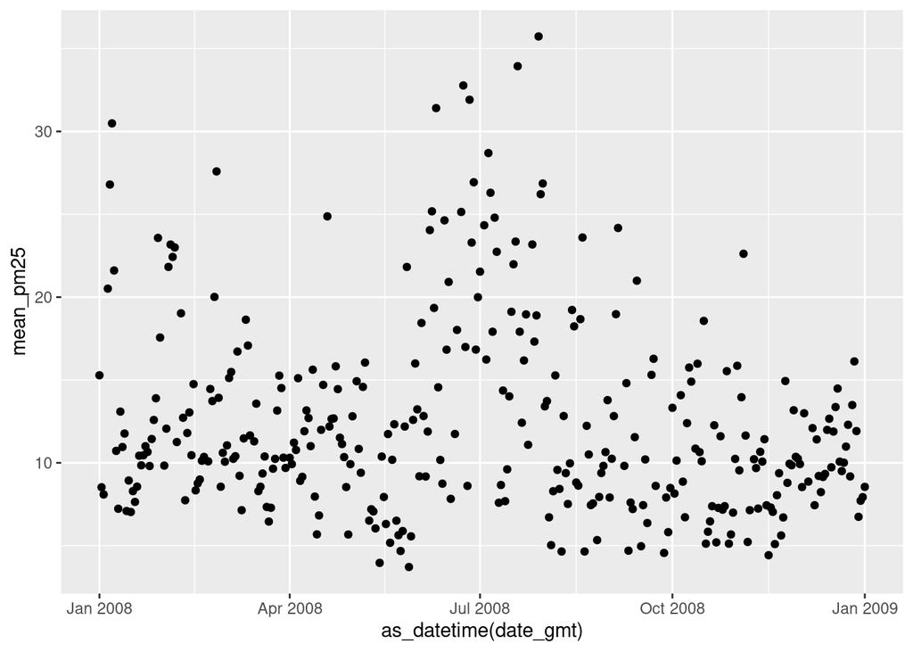

```r
epa_sample_data$Data |> tibblify() |> select(date_gmt,sample_measurement) |> group_by(date_gmt) |>
  summarise(mean_pm25 = mean(sample_measurement)) |> ggplot(aes(x=as_datetime(date_gmt),y=mean_pm25)) +
  geom_point() +
  scale_x_datetime()
```

## Conclusion

I’m surprised at how noisy the PM2.5 measurements are from this single site in Manhttan. Although there is substantial noise, it does seem like July is a month with much worse air quality than other months, at least in 2008.